# CPI All Items

## Goal

Explore the distribution of the cleaned **monthly** observations for CPI All Items. Each value has equal weight within this native series. The notebook is independent of the other analysis notebooks.

## Context & Methods

- Read the cleaned CSV and its metadata/audit directly; cleaning remains outside this notebook.
- Use original cleaned levels, not growth rates or standardized values. No observations are filled, resampled, trimmed, or winsorized.
- The histogram covers the entire retained range. Automatic bin edges use NumPy's `auto` rule, capped at 80 bins for readability.
- The box spans the 25th to 75th percentile; its line is the median. Whiskers extend to observations within 1.5 interquartile ranges of the box. Points beyond them are shown, not deleted or declared erroneous.
- This is a full-history empirical distribution. Trends and changing conditions can shape it; it is not a fitted probability model or a stationary benchmark.
- The project does not record measurement units explicitly. Axes therefore say **native file units** rather than guessing units or an index base.

Run all cells with the packages in `requirements-notebook.txt`. Paths work from this folder or the project root.

## Data

### Load the cleaned native series

|  | Value |
| --- | --- |
| Dataset | CPI All Items |
| Source | FRED |
| Expected frequency | monthly |
| Inferred frequency | monthly |
| Start date | 1947-01-01 |
| End date | 2026-08-01 |
| Observations | 955 |
| Clean missing values | 0 |

**Existing cleaning note:** missing_value_rows_removed=1; Suspicious gaps=1

Source: `data/cleaned/CPIAUCSL.csv`. Dates and values are preserved.

## Results

### Descriptive statistics

|  | Value |
| --- | --- |
| Observations | 955.0000 |
| Mean | 125.5859 |
| Sample standard deviation | 90.8308 |
| Minimum | 21.4800 |
| 25th percentile | 32.8900 |
| Median | 110.2000 |
| 75th percentile | 202.4000 |
| Maximum | 334.1310 |

### Histogram and box plot

The histogram counts observed values, including extreme observations. The box plot shares the same horizontal scale so the full range and central spread can be compared directly.

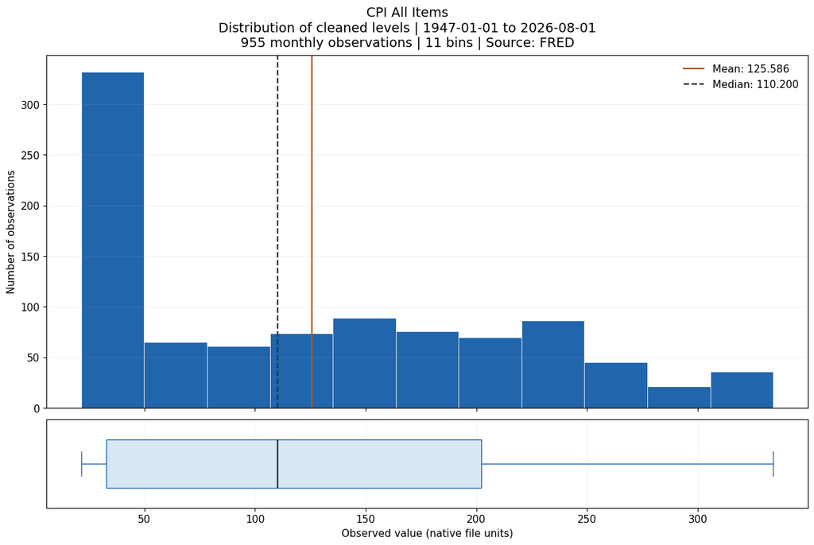

## Checks & Takeaways

**955 observations** are plotted over the full retained range, **21.480 to 334.131**, with a median of **110.200**. Mean and median summarize the pooled history; their positions do not establish normality or stationarity. Points beyond the box-plot whiskers remain in the data.

```
Validated histogram count and unchanged source files. Exports: C:\Users\HYPE AMD\Desktop\CHronoZ-Economic-Modelling\outputs\distributions\CPIAUCSL
```